# R 中心极限定理

Li Zongzhang

2023-04-20

# for loop

```r
for (i in 1:5) {
  print(i)
}
```

```
[1] 1
[1] 2
[1] 3
[1] 4
[1] 5
```

```r
for (i in seq(0,10,2)) {
  print(c(i,i^2))
}
```

```
[1] 0 0
[1] 2 4
[1]  4 16
[1]  6 36
[1]  8 64
[1]  10 100
```

```r
#for loop
a <- numeric(5)
for (i in 1:5) {
  a[i] <- i^2
}
a
```

```
[1]  1  4  9 16 25
```

```r
for (i in 1:5) {
  for (j in 1:2) {
    print(i+j)
    }
}
```

```
[1] 2
[1] 3
[1] 3
[1] 4
[1] 4
[1] 5
[1] 5
[1] 6
[1] 6
[1] 7
```

```r
for (i in 1:5) {
  for (j in 1:2)
  {print(i+j)}
  }
```

```
[1] 2
[1] 3
[1] 3
[1] 4
[1] 4
[1] 5
[1] 5
[1] 6
[1] 6
[1] 7
```

# 中心极限定理的模拟

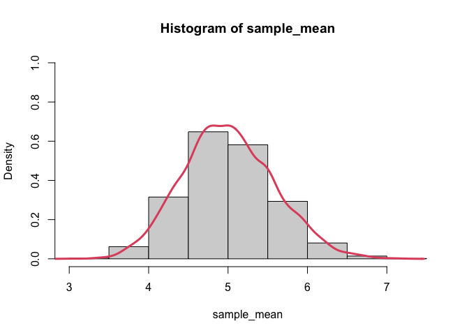

```r
#Central Limit Theorem
sample_mean <- array(0,dim=5000)
for (i in 1:5000){
  x <- rchisq(30,5)
  sample_mean[i] <- mean(x)
}
hist(sample_mean,prob = T,ylim = c(0,1))
lines(density(sample_mean),col=2,lwd=3)
```

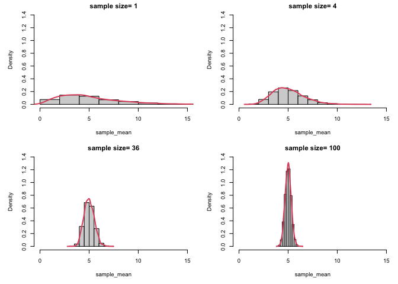

```r
#总体服从自由度为5的卡方分布
par(mfrow = c(2,2),mai = c(0.6,0.6,0.2,0.1),cex = 0.6)
sample_size <-  c(1,4,36,100)
for (j in 1:4){
  sample_mean <- array(0,dim=5000)
  for (i in 1:5000){
    x <- rchisq(sample_size[j],5)
    sample_mean[i] <- mean(x)
  }
  hist(sample_mean, freq = F,
       xlim=c(0,15),
       ylim=c(0,1.4),
       main = paste("sample size=", sample_size[j]))
  lines(density(sample_mean),col=2,lwd=2)
}
```

# 本章习题

## 练习1: 中心极限定理的模拟——总体服从卡方分布

总体分布服从自由度为10的卡方分布。完成下列要求：

1. 从总体中抽取1个个案组成一个样本，计算该样本的均值。重复该过程1000次，绘制这1000个样本的样本均值的直方图和概率密度曲线。
2. 从总体中抽取5个个案组成一个样本，计算该样本的均值。重复该过程1000次，绘制这1000个样本的样本均值的直方图和概率密度曲线。
3. 从总体中抽取30个个案组成一个样本，计算该样本的均值。重复该过程1000次，绘制这1000个样本的样本均值的直方图和概率密度曲线。
4. 从总体中抽取100个个案组成一个样本，计算该样本的均值。重复该过程1000次，绘制这1000个样本的样本均值的直方图和概率密度曲线。
5. 简要描述上述4组图形的相同和不同之处。

作答要求：上传代码、图形输出和简要文字回答

## 练习2: 中心极限定理的模拟——总体服从均匀分布

总体分布服从（0，10）的均匀分布。完成下列要求：

1. 从总体中抽取1个个案组成一个样本，计算该样本的均值。重复该过程1000次，绘制这1000个样本的样本均值的直方图和概率密度曲线。
2. 从总体中抽取5个个案组成一个样本，计算该样本的均值。重复该过程1000次，绘制这1000个样本的样本均值的直方图和概率密度曲线。
3. 从总体中抽取30个个案组成一个样本，计算该样本的均值。重复该过程1000次，绘制这1000个样本的样本均值的直方图和概率密度曲线。
4. 从总体中抽取100个个案组成一个样本，计算该样本的均值。重复该过程1000次，绘制这1000个样本的样本均值的直方图和概率密度曲线。
5. 简要描述上述4组图形的相同和不同之处。。

作答要求：上传代码、图形输出和简要文字回答。

## 练习3: 中心极限定理的模拟——总体服从正态分布

总体分布服从正态分布（自行设定正态分布的均值和标准差）。完成下列要求：

1. 从总体中抽取1个个案组成一个样本，计算该样本的均值。重复该过程1000次，绘制这1000个样本的样本均值的直方图和概率密度曲线。
2. 从总体中抽取5个个案组成一个样本，计算该样本的均值。重复该过程1000次，绘制这1000个样本的样本均值的直方图和概率密度曲线。
3. 从总体中抽取30个个案组成一个样本，计算该样本的均值。重复该过程1000次，绘制这1000个样本的样本均值的直方图和概率密度曲线。
4. 从总体中抽取100个个案组成一个样本，计算该样本的均值。重复该过程1000次，绘制这1000个样本的样本均值的直方图和概率密度曲线。
5. 简要描述上述4组图形的相同和不同之处。

作答要求：上传代码、图形输出和简要文字回答。